# IS 605 Final Exam

Oluwakemi Omotunde

May 15, 2017

Pick **one** of the quantitative independent variables from the training data set (train.csv) , and define that variable as X. Pick **SalePrice** as the dependent variable, and define it as Y for the next analysis.

```r
train.data <- read.csv("https://raw.githubusercontent.com/komotunde/DATA605/master/train.csv", header  = TRUE)
head(train.data)
```

```
##   Id MSSubClass MSZoning LotFrontage LotArea Street Alley LotShape
## 1  1         60       RL          65    8450   Pave  <NA>      Reg
## 2  2         20       RL          80    9600   Pave  <NA>      Reg
## 3  3         60       RL          68   11250   Pave  <NA>      IR1
## 4  4         70       RL          60    9550   Pave  <NA>      IR1
## 5  5         60       RL          84   14260   Pave  <NA>      IR1
## 6  6         50       RL          85   14115   Pave  <NA>      IR1
##   LandContour Utilities LotConfig LandSlope Neighborhood Condition1
## 1         Lvl    AllPub    Inside       Gtl      CollgCr       Norm
## 2         Lvl    AllPub       FR2       Gtl      Veenker      Feedr
## 3         Lvl    AllPub    Inside       Gtl      CollgCr       Norm
## 4         Lvl    AllPub    Corner       Gtl      Crawfor       Norm
## 5         Lvl    AllPub       FR2       Gtl      NoRidge       Norm
## 6         Lvl    AllPub    Inside       Gtl      Mitchel       Norm
##   Condition2 BldgType HouseStyle OverallQual OverallCond YearBuilt
```

[output cut: 76 more lines]

```r
#I will go ahead and use Sale Price as my dependent variable, as requested so it'll be my Y. For my X variable (independent), I will use Total Basement Square Footage.

X <- train.data$TotalBsmtSF
Y <- train.data$SalePrice
```

*Probability*. Calculate as a minimum the below probabilities a through c. Assume the small letter “x” is estimated as the 4th quartile of the X variable, and the small letter “y” is estimated as the 2nd quartile of the Y variable. Interpret the meaning of all probabilities.

1. P(X > x |Y > y) = .4519231

```r
require(dplyr)
x <- quantile(X, .75) #x is the estimated 4th quartile of X
y <- quantile(Y, .5) #y is the estimated 2nd quartile of Y

num <- filter(train.data, SalePrice > y & TotalBsmtSF > x) %>% tally()/nrow(train.data)
den <- filter(train.data, SalePrice > y) %>% tally()/nrow(train.data)
p1 <- num/den
p1
```

```
##           n
## 1 0.4519231
```

Below is how I arrived at the above code.

```r
num.b <- filter(train.data, TotalBsmtSF > x) %>% tally()/nrow(train.data)
den.b <- filter(train.data, SalePrice > y) %>% tally()/nrow(train.data)
p2 <- num.b * den.b
p2
```

```
##           n
## 1 0.1246575
```

```r
num.c <- filter(train.data, SalePrice > y & TotalBsmtSF < x) %>% tally()/nrow(train.data)
den.c <- filter(train.data, SalePrice > y) %>% tally()/nrow(train.data)
p3 <- num.c/den.c
p3
```

```
##           n
## 1 0.5480769
```

Does splitting the training data in this fashion make them independent? In other words, does P(X|Y)=P(X)P(Y))? Check mathematically, and then evaluate by running a Chi Square test for association. You might have to research this.

```r
filter(train.data, SalePrice <= y & TotalBsmtSF <=x) %>% tally() #696
```

```
##     n
## 1 696
```

```r
filter(train.data, SalePrice > y & TotalBsmtSF <=x) %>% tally() #399
```

```
##     n
## 1 399
```

```r
filter(train.data, TotalBsmtSF <=x) %>% tally() #1095
```

```
##      n
## 1 1095
```

```r
filter(train.data, SalePrice <= y & TotalBsmtSF > x) %>% tally() #36
```

```
##    n
## 1 36
```

```r
filter(train.data, SalePrice > y & TotalBsmtSF > x) %>% tally() #329
```

```
##     n
## 1 329
```

```r
filter(train.data, TotalBsmtSF > x) %>% tally()#365
```

```
##     n
## 1 365
```

```r
filter(train.data, SalePrice <= y) %>% tally() #732
```

```
##     n
## 1 732
```

```r
filter(train.data, SalePrice > y) %>% tally() #728
```

```
##     n
## 1 728
```

```r
nrow(train.data)#1460
```

```
## [1] 1460
```

```r
P.A = 365/1460  #.25
P.A
```

```
## [1] 0.25
```

```r
P.B = 728/1460 #.5
P.B
```

```
## [1] 0.4986301
```

```r
P.AB = P.A * P.B
P.AB
```

```
## [1] 0.1246575
```

```r
#P(X > x |Y > y) = .4519231

#We can see mathematically that these two variables are dependent.
```

It does not appear that splitting up the data makes them independent. We will perform th Chi Square test to verify our mathematical findings

```r
chi.test <- table(train.data$SalePrice, train.data$TotalBsmtSF)
#now we will do the chi test to find our signifance level

chisq.test(chi.test)
```

```
##
##  Pearson's Chi-squared test
##
## data:  chi.test
## X-squared = 509710, df = 476640, p-value < 2.2e-16
```

```r
#Since our p-value is significantly less than .05, we can reject the null hypothesis stating that X and Y are independent. That is to say that there is dependence between the Sale Price and the Total Basement Square Foot.
```

*Descriptive and Inferential Statistics.* Provide univariate descriptive statistics and appropriate plots for both variables(SalePrice and TotalBsmtSF). * **TotalBsmtSF:** Total square feet of basement area * **SalePrice:** Price house sold for + I assumed on this description as it was not on the data description list.

```r
require(ggplot2)
summary(train.data$SalePrice)
```

```
##    Min. 1st Qu.  Median    Mean 3rd Qu.    Max.
##   34900  129975  163000  180921  214000  755000
```

```r
summary(train.data$TotalBsmtSF)
```

```
##    Min. 1st Qu.  Median    Mean 3rd Qu.    Max.
##     0.0   795.8   991.5  1057.4  1298.2  6110.0
```

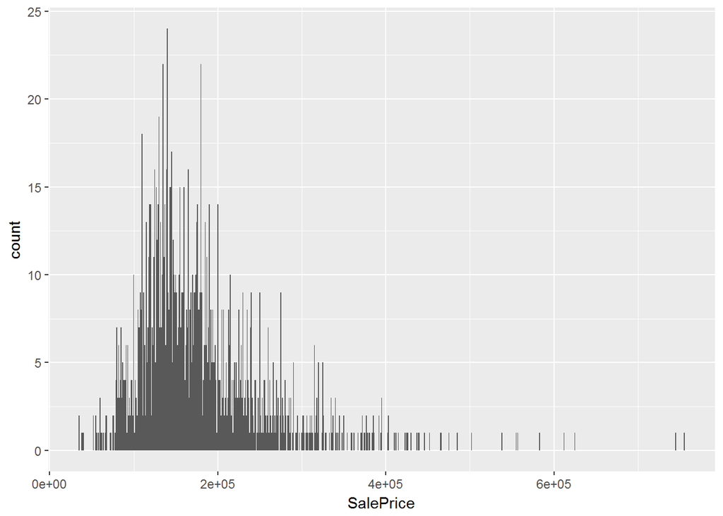

```r
ggplot(data=train.data, aes(SalePrice)) + geom_histogram(binwidth = 1000)
```

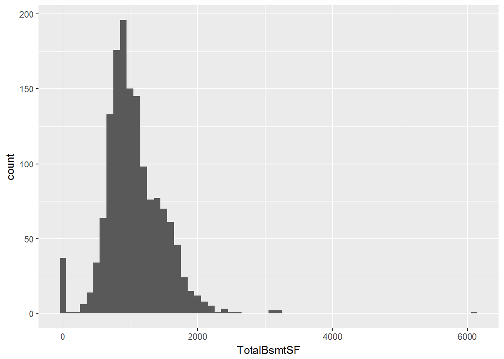

```r
#This plot looks slightly skewed to the right.

ggplot(data=train.data, aes(TotalBsmtSF)) + geom_histogram(binwidth = 100)
```

```r
#This plot also looks slightly skewed to the right.
```

Provide a scatterplot of X and Y.

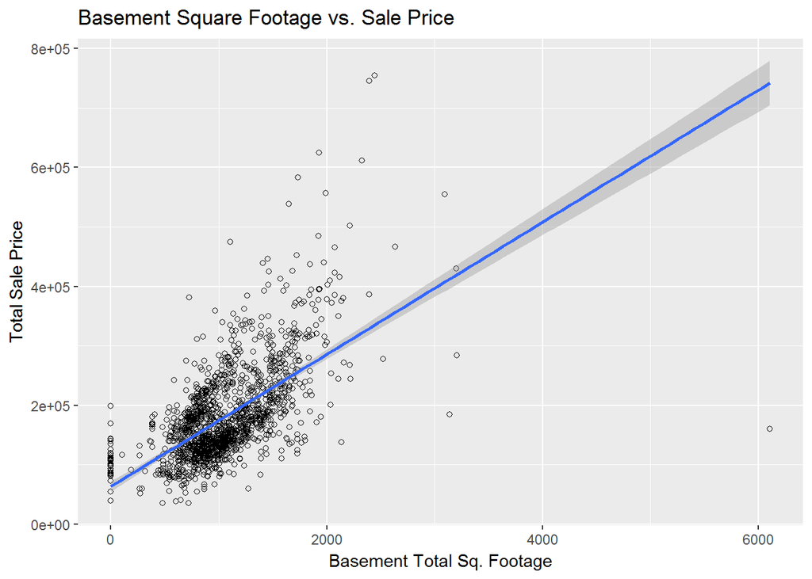

```r
ggplot(train.data, aes(x = TotalBsmtSF, y = SalePrice)) + geom_point(shape = 1) + geom_smooth(method = lm) + labs(x = "Basement Total Sq. Footage", y = "Total Sale Price", title = "Basement Square Footage vs. Sale Price")
```

```r
#I used geom_smooth to add a linear regression line which is by default a 95% confidence interval region
```

Transform both variables simultaneously using Box-Cox transformations.You might have to research this.

```r
#I found a lot of useful information on the following website:  http://rstudio-pubs-static.s3.amazonaws.com/63893_9f6bc9cd73ad47aab3aa85d0193244d9.html

require(MASS)
```

```r
bc <- lm(train.data$SalePrice ~ train.data$TotalBsmtSF)
trans <- boxcox(bc, lambda=seq(-2,2,.1), plotit = FALSE, interp = TRUE)
trans.test.data <- as.data.frame(trans)
lamda <- trans.test.data[which.max(trans$y),1]
lamda #0.02020202
```

```
## [1] 0.02020202
```

```r
new.data <- cbind(X, Y, train.data$SalePrice^lamda, train.data$TotalBsmtSF^lamda)
colnames(new.data) <- c("TotalBsmtSF", "SalePrice", "Trans.SalePrice", "Trans.TB")
head(new.data)
```

```
##      TotalBsmtSF SalePrice Trans.SalePrice Trans.TB
## [1,]         856    208500        1.280727 1.146151
## [2,]        1262    181500        1.277144 1.155175
## [3,]         920    223500        1.282526 1.147822
## [4,]         756    140000        1.270463 1.143278
## [5,]        1145    250000        1.285433 1.152906
## [6,]         796    143000        1.271008 1.144470
```

Using the transformed variables, run a correlation analysis and interpret. Test the hypothesis that the correlation between these variables is 0 and provide a 99% confidence interval.Discuss the meaning of your analysis.

```r
#For some odd reason, it was not easy for me to subset the data frame for just the columns I need. I used this site for assistance: https://stackoverflow.com/questions/10085806/extracting-specific-columns-from-a-data-frame

trans.data <- new.data[,c("Trans.SalePrice", "Trans.TB")]
head(trans.data)
```

```
##      Trans.SalePrice Trans.TB
## [1,]        1.280727 1.146151
## [2,]        1.277144 1.155175
## [3,]        1.282526 1.147822
## [4,]        1.270463 1.143278
## [5,]        1.285433 1.152906
## [6,]        1.271008 1.144470
```

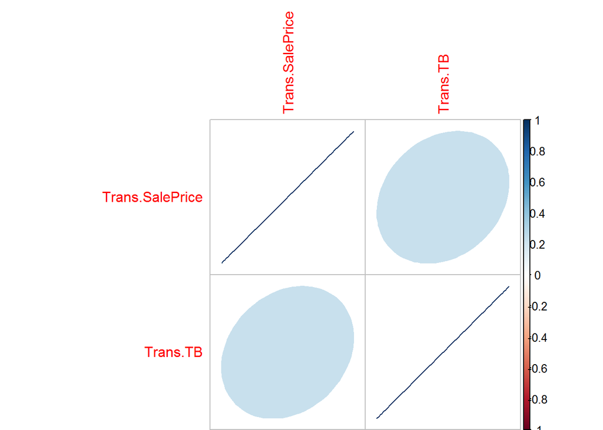

```r
require(corrplot)
require(stats)
corr. <- cor(trans.data)
corrplot(corr., method = "ellipse")
```

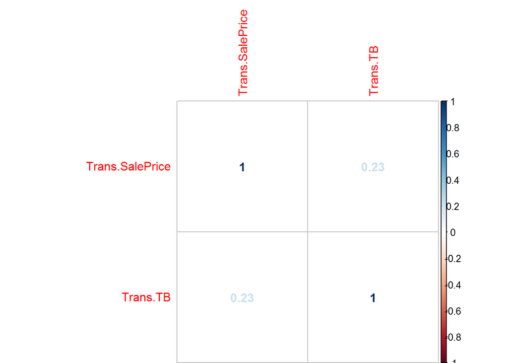

```r
corrplot(corr., method = "number")
```

```r
#https://cran.r-project.org/web/packages/corrplot/vignettes/corrplot-intro.html
TSP <- new.data[,"Trans.SalePrice"]
TTB <- new.data[,"Trans.TB"]
TBSF <- new.data[,"TotalBsmtSF"]
SP <- new.data[,"SalePrice"]

c.test <- cor.test(TSP,TTB,  method = "pearson", conf.level = .99)
c.test
```

```
##
##  Pearson's product-moment correlation
##
## data:  TSP and TTB
## t = 8.844, df = 1458, p-value < 2.2e-16
## alternative hypothesis: true correlation is not equal to 0
## 99 percent confidence interval:
##  0.1607066 0.2886342
## sample estimates:
##       cor
## 0.2256429
```